# **Loan Prediction**

Even though this is an Analytics Vidhya competition, my goal in this project is not to compete or to construct the most accurate model but to demonstrate basic skills of tackling cleaned datasets that includes: handling missing values, exploratory analysis, feature engineering, building predictive model, tuning model parameters, and model evaluation, as well as gaining insights from data and model. The goal of this problem is to predict the status of loan approval of test data set as accurate as possible.

## Data Preprocessing

#### Loading essential packages

```r
suppressMessages(library(ggplot2))
suppressMessages(library(gridExtra))
suppressMessages(library(dplyr))
suppressMessages(library(mice))
suppressMessages(library(randomForest))
suppressMessages(library(rpart))
suppressMessages(library(Hmisc))
```

#### Reading data from csv

```r
setwd("C:/Users/Jimmy Chen/Desktop/Project")
train<-read.csv("loantrain.csv")
test<-read.csv("loantest.csv")
```

#### First look at train data

```r
str(train)
```

#### Data Cleaning

```r
#turn binary variable Credit_History into factor
train$Credit_History<-factor(train$Credit_History,labels = c("N","Y"))
test$Credit_History<-factor(test$Credit_History,labels = c("N","Y"))

#convert factor variable Dependents into numeric
levels(train$Dependents)[levels(train$Dependents)=="3+"] <- "3"
train$Dependents<-as.integer(as.character(train$Dependents))
levels(test$Dependents)[levels(test$Dependents)=="3+"] <- "3"
test$Dependents<-as.integer(as.character(test$Dependents))

#remove the id column
train<-train[-1]

#some NA's are coded as empty strings
train$Gender[train$Gender==""] <- NA
train$Married[train$Married==""] <- NA
train$Self_Employed[train$Self_Employed==""] <- NA
test$Gender[test$Gender==""] <- NA
test$Married[test$Married==""] <- NA
test$Self_Employed[test$Self_Employed==""] <- NA

train$Married<-droplevels(train$Married) #test data does not have the empty level as train data does
```

```r
summary(train)
```

```
##     Gender    Married      Dependents            Education   Self_Employed
##        :  0   No  :213   Min.   :0.0000   Graduate    :480       :  0
##  Female:112   Yes :398   1st Qu.:0.0000   Not Graduate:134   No  :500
##  Male  :489   NA's:  3   Median :0.0000                      Yes : 82
##  NA's  : 13              Mean   :0.7629                      NA's: 32
##                          3rd Qu.:2.0000
##                          Max.   :3.0000
##                          NA's   :15
##  ApplicantIncome CoapplicantIncome   LoanAmount    Loan_Amount_Term
##  Min.   :  150   Min.   :    0     Min.   :  9.0   Min.   : 12
##  1st Qu.: 2878   1st Qu.:    0     1st Qu.:100.0   1st Qu.:360
##  Median : 3812   Median : 1188     Median :128.0   Median :360
##  Mean   : 5403   Mean   : 1621     Mean   :146.4   Mean   :342
##  3rd Qu.: 5795   3rd Qu.: 2297     3rd Qu.:168.0   3rd Qu.:360
##  Max.   :81000   Max.   :41667     Max.   :700.0   Max.   :480
##                                    NA's   :22      NA's   :14
##  Credit_History   Property_Area Loan_Status
##  N   : 89       Rural    :179   N:192
##  Y   :475       Semiurban:233   Y:422
##  NA's: 50       Urban    :202
##
##
##
##
```

#### Outliers detection

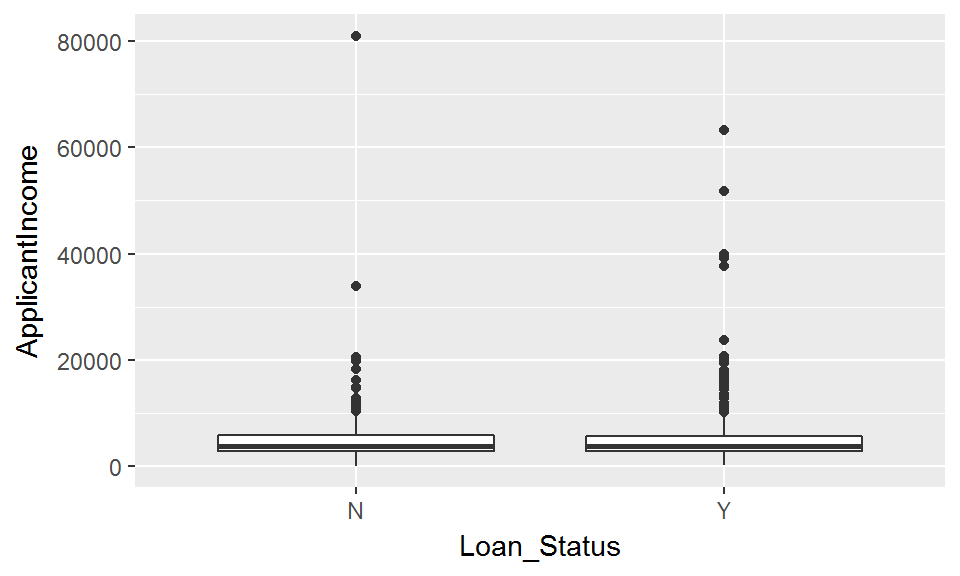

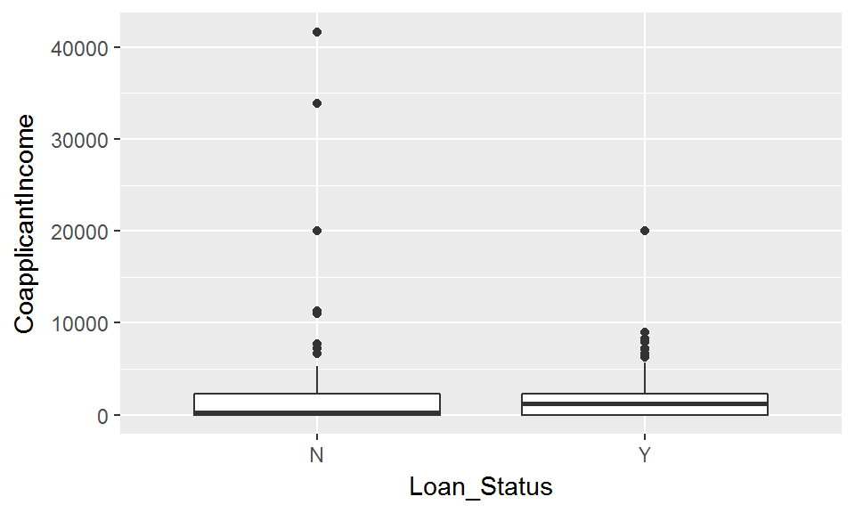

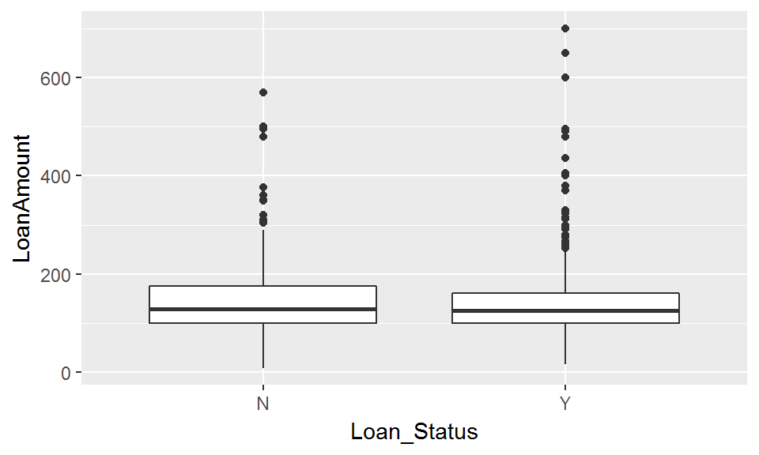

Even though there are serveral extreme points, it seems not to be mistakenly inputed, therefore we are not going to remove them from the dataset. Moreover, the boxplots of numeric variables look similiar for different loan status, the distinction seems not strong looking from individual features.

#### Missing values treatment

```r
#create a new feature of the number of Na in an observation
train_NAs<-NULL
test_NAs<-NULL
for(i in 1:nrow(train)) train_NAs[i]<-sum(is.na(train[i, ]))
train$NA_number<-train_NAs
for(i in 1:nrow(test)) test_NAs[i]<-sum(is.na(test[i, ]))
test$NA_number<-test_NAs
#the ratio of missing for each variable
names<-names(train)
missing<-data.frame(variable=names,missing_proportion=sapply(names,function(x) sum(is.na(train[x]))/nrow(train)))
missing #The missing rate does not exceed 10%

#input missing values by package mice, considering that the missing values are not MNAR(missing not at random)
trainimp<-mice(data=train,m=5,maxit = 10,method="pmm",printFlag=FALSE,seed=0817) #estimate fitting values for continuous variables using predictive mean matching of mice
newtrain<-complete(trainimp) #imput the estimated missing values
sum(is.na(newtrain)) #all missing value are imputed

testimp<-mice(data=test[-1],m=5,maxit = 10,method="pmm",printFlag=FALSE,seed=0817)
newtest<-complete(testimp) #imput the estimated missing values for test dataset as well
```

## Exploratory Analysis

This section is an important part in the analysis. By plotting exploratory graphs, we gain better idea of the data. This section will be breaken into two parts, univariate visualization and variables against response. To avoid taking too much space, not all graphs done will be presented below.

#### Univariate visualization

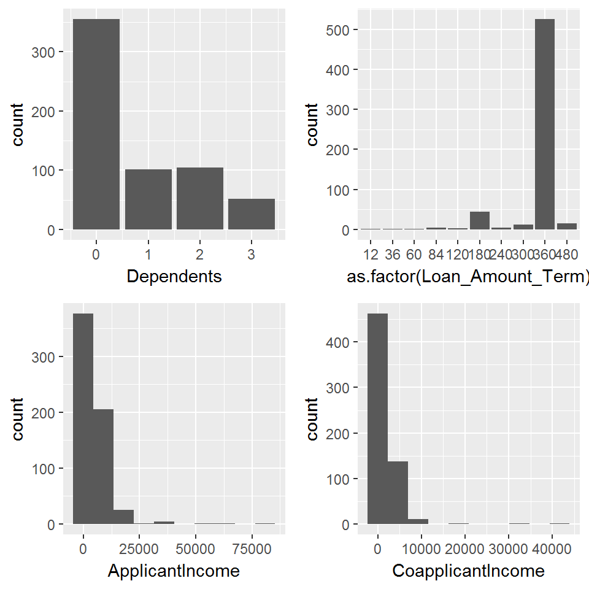

#### Variables against response

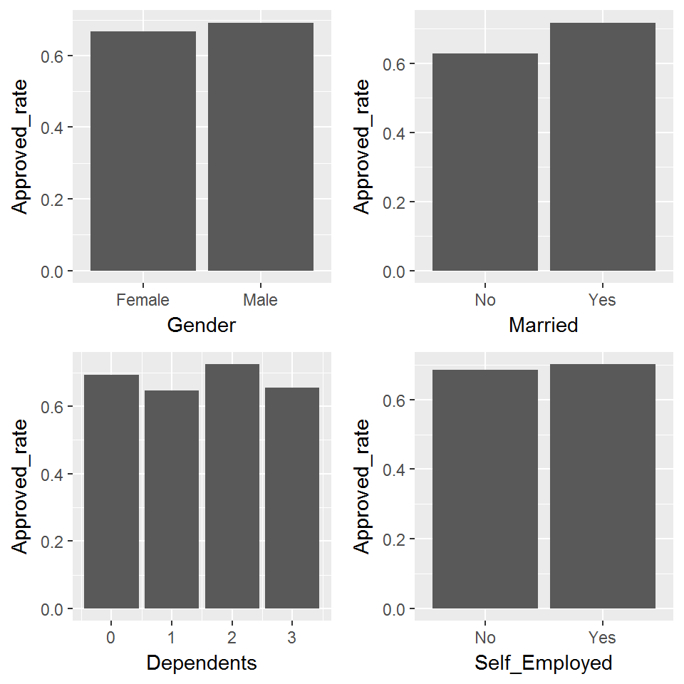

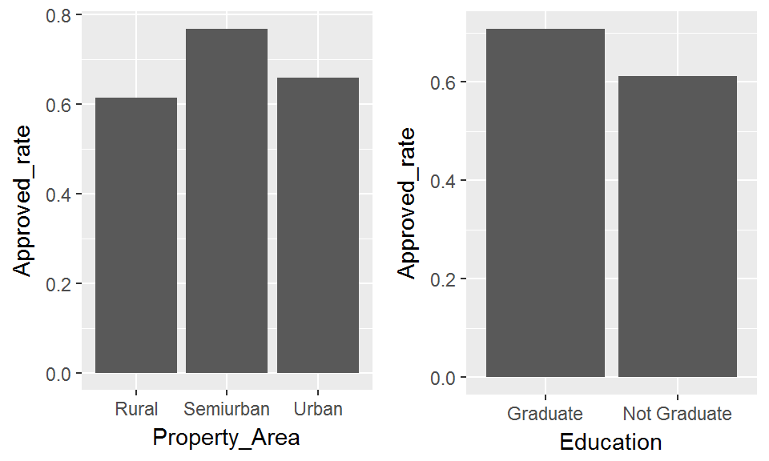

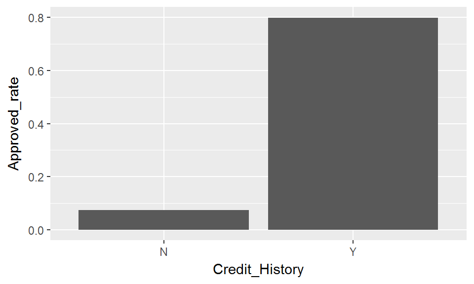

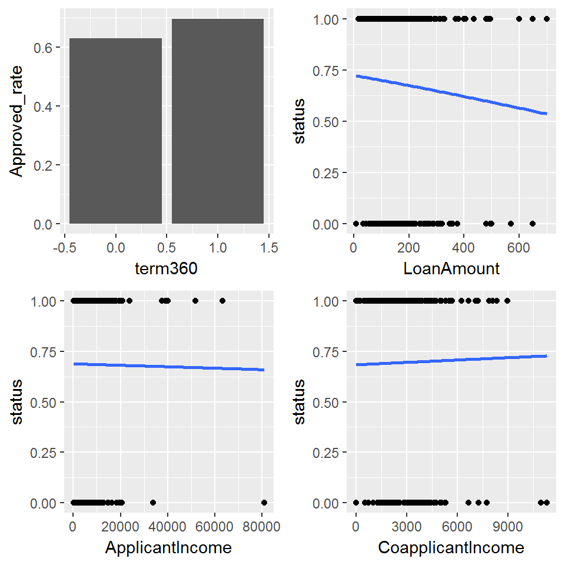

Some interesting discovery from above plots and statical tests (t test and ANOVA ran in console) are :

- Features that are significant indivually include property area, education, loan amount, and lastly credit history, which is the strongest among all
- Some variables such as applicant income and coapplicant income are not significant alone, which is strange since by intutition they should be important. Therefore, we will plot them together in the feature engineering section to see if there exists interaction that distinguishes the response well.

## Feature engeneering

This part is crucial to the analysis, since features should be combined or transformed someway in order to build a better model. Therefore, we will make serveral graphs below to determine which combination or transformation of variables can be added as new features.

##### Adding up the two kind of income

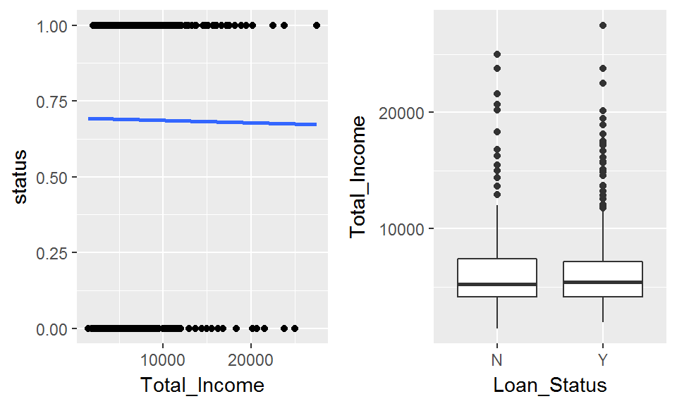

Adding up the total seems to be not significant by itself.

# Dividing the loan amount by total income

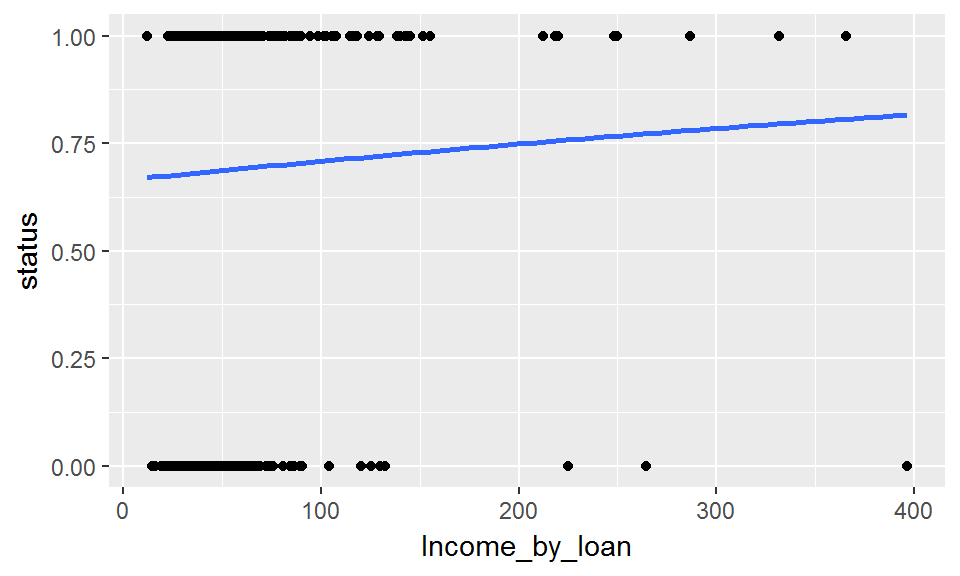

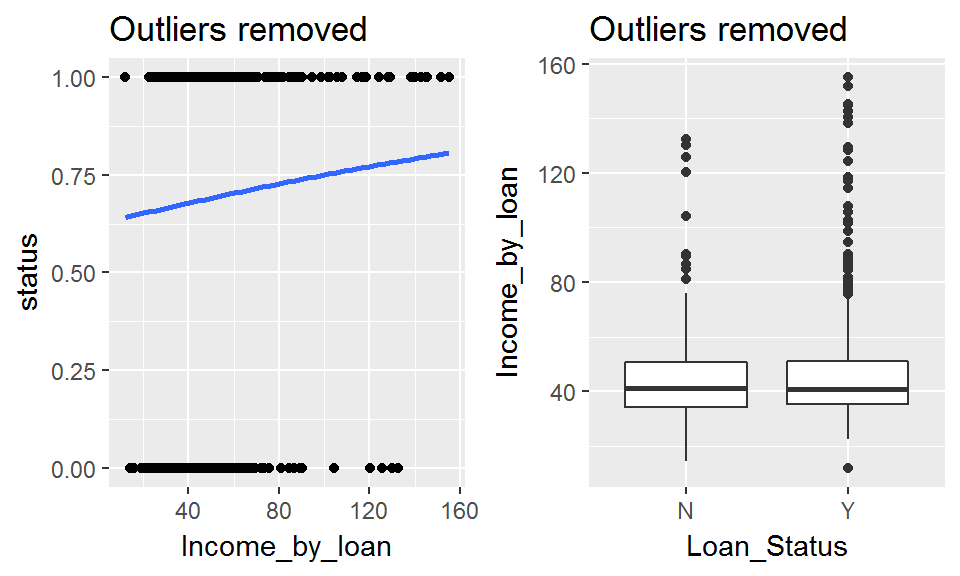

#### Does it matter if there is no coapplicant?

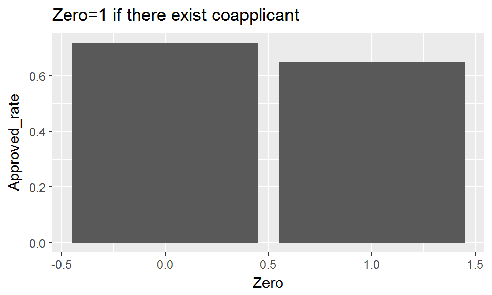

```
##
##  Welch Two Sample t-test
##
## data:  newtrain$status by newtrain$Zero
## t = 1.8523, df = 566.73, p-value = 0.0645
## alternative hypothesis: true difference in means is not equal to 0
## 95 percent confidence interval:
##  -0.004232704  0.144479554
## sample estimates:
## mean in group 0 mean in group 1
##       0.7184751       0.6483516
```

#### High total income but low applicant income?

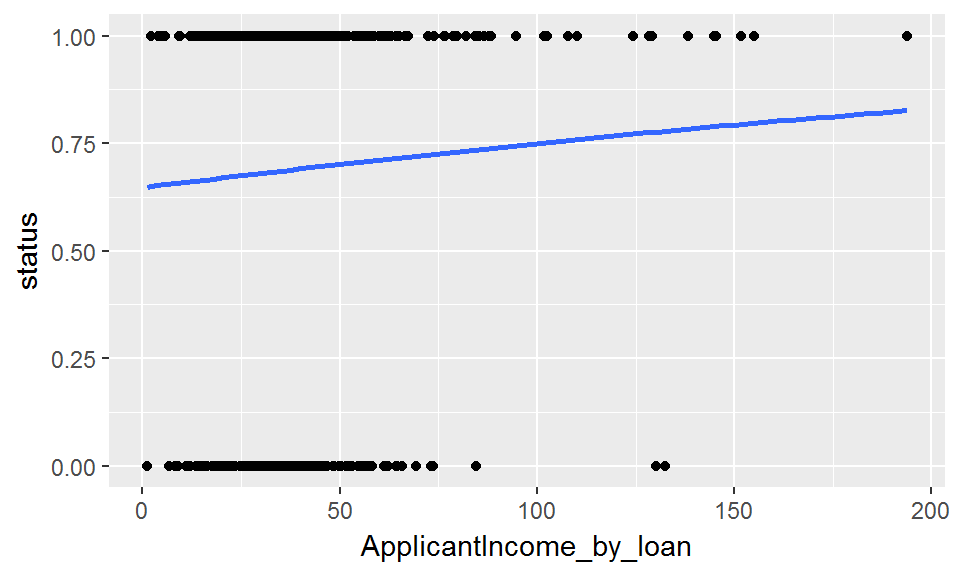

We will add this variable, since sometimes total income by loan amount itself will left out applicants that have low income but high coapplicant income

New features added to the original data set are:

- NA_number: The number of missing value each row before missing value imputation
- Zero: A dummy variable of whether there is co-applicant or not
- Income_by_loan: The sum of applicant and co-applicant income, then divided by loan amount
- ApplicantIncome_by_loan: The sum of applicant income itself, dived by loan amount

```r
#remove unneeded variables
newtrain$term360<-NULL
newtrain$status<-NULL
newtrain$Total_Income<-NULL
```

## Model building and tuning

For this problem, we will use Random Forest as our prediction model, since it has the following advantages:

- It works very well in classification problem.
- It is strong with outliers, irrelevant variables, and a mix of continuous and discrete variables.
- It produces out of bag estimate error which has proven to be unbiased in many tests.
- It is relatively easy to tune with.

As for the evaluation method, we will choose “Accuracy” since the aim of this project is to correctly predict as many cases as possible. However, for others, “Accuracy” might not be a good evaluation method, for example, imbalanced data or cases that you care one of false negative or false positive signals a lot more than the other.

Finally, we will tune the two parameters below of the random forest model, since they are most likely to have the biggest effect on our final accuracy.

- mtry: Number of variables randomly sampled as candidates at each split.
- ntree: Number of trees to grow.

#### Model without tuning

```r
set.seed(91)
original_rf<-randomForest(Loan_Status~ .,newtrain[-c(13:16)])
original_rf
```

```
##
## Call:
##  randomForest(formula = Loan_Status ~ ., data = newtrain[-c(13:16)])
##                Type of random forest: classification
##                      Number of trees: 500
## No. of variables tried at each split: 3
##
##         OOB estimate of  error rate: 19.06%
## Confusion matrix:
##    N   Y class.error
## N 95  97  0.50520833
## Y 20 402  0.04739336
```

```r
# base model without feature engineering has an OOB error rate of 19.06%
feature_engineered_rf<-randomForest(Loan_Status~.,newtrain)
feature_engineered_rf
```

```
##
## Call:
##  randomForest(formula = Loan_Status ~ ., data = newtrain)
##                Type of random forest: classification
##                      Number of trees: 500
## No. of variables tried at each split: 3
##
##         OOB estimate of  error rate: 16.94%
## Confusion matrix:
##     N   Y class.error
## N 105  87  0.45312500
## Y  17 405  0.04028436
```

```r
# base model with additional variables has a better OOB error rate 16.94%
```

It is clear that model with feature learning has a better accuracy than the original one. Therefore, we will choose to use it as our base model and proceed to model tuning.

#### Tuning Model

```r
set.seed(18)
tune_grid<-expand.grid(mtry=c(1:10), ntree=c(500,1000,1500,2000)) #expand a grid of parameters
mtry<-tune_grid[[1]]
ntree<-tune_grid[[2]] #using vectors instead of dataframe to subset is faster in for loop
OOB<-NULL #use to store calculated OOB error estimate
for(i in 1:nrow(tune_grid)){
  rf<-randomForest(Loan_Status~. ,newtrain, mtry=mtry[i], ntree=ntree[i])
  confusion<-rf$confusion
  temp<-(confusion[2]+confusion[3])/614 #calculate the OOB error estimate
  OOB<-append(OOB,temp)
}
tune_grid$OOB<-OOB
head(tune_grid[order(tune_grid["OOB"]), ], 4) #order the results
```

```
##    mtry ntree       OOB
## 3     3   500 0.1693811
## 33    3  2000 0.1693811
## 12    2  1000 0.1726384
## 2     2   500 0.1742671
```

```r
final_rf<-randomForest(Loan_Status~. ,newtrain, mtry=3, ntree=1000)
```

#### Predicting with model

```r
#rf
predictions<-unname(predict(final_rf,newtest[]))
solution<-data.frame(Loan_ID=test[1],Loan_Status=predictions) #predict the test set
write.csv(solution,"SolutionChecker.csv") #write the predicted result into solution checker file
```

## Finding insights

For this section, we will plot the variance importantance plot, partial dependence plots, and simple decision trees to gain insight from the model.

#### Variance importance plot

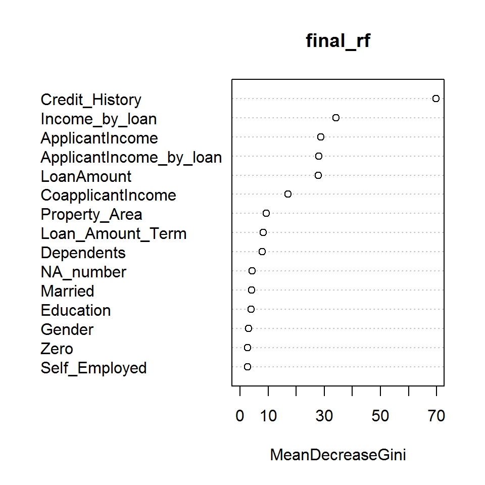

As we had expected, the most significant variables according to the plot is Credit History, following by Total income by loan, Applicant income, Applicant income by loan, and loan amount. Two of the four engineered feature seems to work well, while the other two: NA’s number and Zero does not contribute much to the model. Let’s check the partial dependence plots for the top six variables.

#### Partial dependence plot

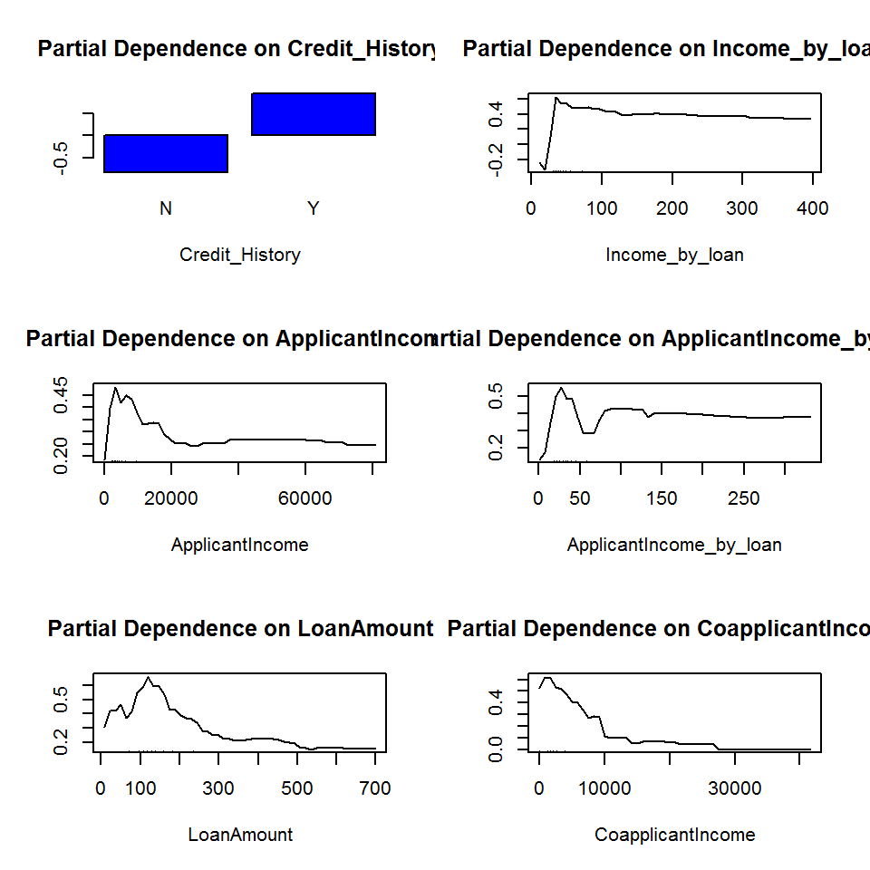

#### Sample decision tree

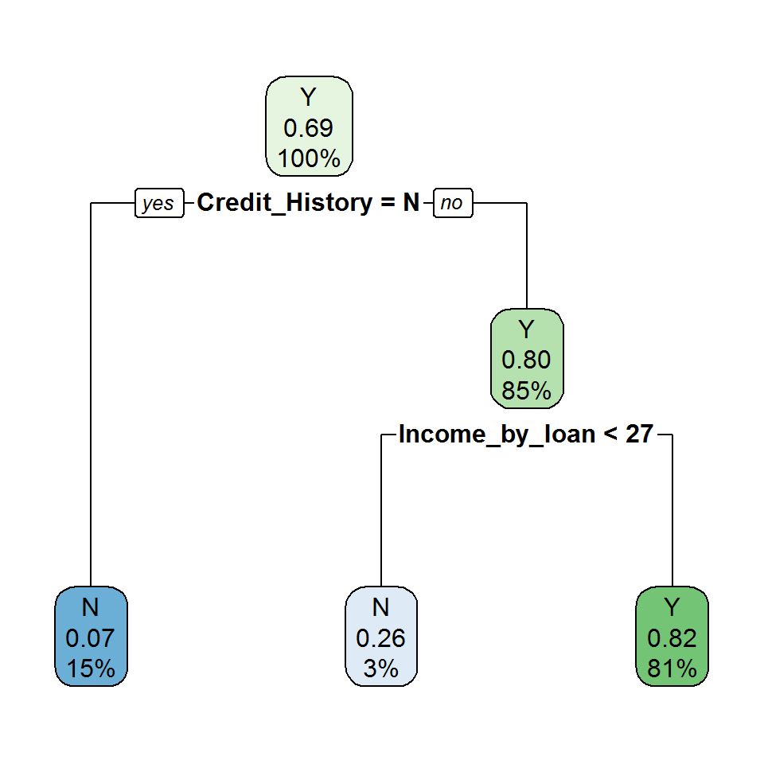

A simple decision tree coincides with random forest’s finding: Credit history and Income by loan is the strongest variable among all, and the plot illustrate how the model works.

## Conclusion

This is the end of the analysis, we started from data cleaning and processing, missing value imputation with mice package, then exploratory analysis and feature engineering, and finally model building and evaluation. The best accuracy on public test set is 0.805556, ranking 33rd on public score board among about 1000 participants, however, the score on private scoreboard has not released yet. What is more important, we gain some insights about loan approval from our analyis, described below.